# Proyecto final Fundamentos de Analítica I

Lizeth Llanos y Diego Agudelo

12/8/2019

```r
library(reshape2)
library(ggplot2)
library(caret)
library(MASS)
library(naivebayes)
library(dplyr)
library(stringr)
library(XML)
library(RCurl)
library(MLeval)
library(rpart)
library(rpart.plot)
library(gridExtra)
library(grid)
library(randomForest)
library(MASS)
library(factoextra)
library(FactoMineR)
library(fpc)
library(cluster)
library(corrplot)


options(warn=-1)
`%notin%` <- Negate(`%in%`)
```

El objetivo de este trabajo es implementar los diferentes modelos con el fin de caracterizar y predecir la condición de las páginas web identificadas como benignas o malignas

```r
# Lectura de datos --------------------------------------------------------
setwd("C:/Users/lllanos/Dropbox/ICESI/Semestre I/Fundamentos de analítica I/Proyecto final")
data = read.csv("PF-02-SitiosMalignos.csv", stringsAsFactors = FALSE)

names(data) = tolower(names(data))
```

## 1. Limpieza de datos

Para iniciar los análisis procedemos a realizar una limpieza a los datos que serán utilizados en el modelo. A continuación se describe paso a paso los procesos realizados.

### 1.1 Baseline

El baseline de los datos es la condición de benigno con un 87.87%

```r
# Baseline
prop.table(table(data$tipo))*100
```

```
##
##        0        1
## 87.87198 12.12802
```

### 1.2 Duplicados

```r
# Limpieza de datos -------------------------------------------------------
dim(data)
```

```
## [1] 1781   19
```

```r
sum(duplicated(data))
```

```
## [1] 0
```

```r
str(data)
```

```
## 'data.frame':    1781 obs. of  19 variables:
##  $ url                 : chr  "M0_109" "B0_2314" "B0_911" "B0_113" ...
##  $ largourl            : int  16 16 16 17 17 18 18 19 20 20 ...
##  $ numcarespeciales    : int  7 6 6 6 6 7 6 6 5 5 ...
##  $ codificacion        : chr  "iso-8859-1" "UTF-8" "us-ascii" "ISO-8859-1" ...
##  $ os                  : chr  "nginx" "Apache/2.4.10" "Microsoft-HTTPAPI/2.0" "nginx" ...
##  $ largoheader         : int  263 15087 324 162 124140 NA 345 324 NA NA ...
##  $ pais                : chr  "None" "None" "None" "US" ...
##  $ estado              : chr  "None" "None" "None" "AK" ...
##  $ numpaquetestcp      : int  7 17 0 31 57 11 12 0 0 0 ...
##  $ puertosremotos      : int  0 7 0 22 2 6 0 0 0 0 ...
##  $ numeroips           : int  2 4 0 3 5 9 3 0 0 0 ...
##  $ numbytes            : int  700 1230 0 3812 4278 894 1189 0 0 0 ...
##  $ numpaquetesenviados : int  9 17 0 39 61 11 14 0 2 2 ...
##  $ numpaquetesrecibidos: int  10 19 0 37 62 13 13 0 3 1 ...
##  $ numbytesenviados    : int  1153 1265 0 18784 129889 838 8559 0 213 62 ...
##  $ numbytesrecibidos   : int  832 1230 0 4380 4586 894 1327 0 146 146 ...
##  $ numpaquetesgenerados: int  9 17 0 39 61 11 14 0 2 2 ...
##  $ numpaquetesdns      : int  2 0 0 8 4 0 2 0 2 2 ...
##  $ tipo                : int  1 0 0 0 0 0 0 0 1 1 ...
```

### 1.3 Recodificación de variables y eliminación de variables

Con el fin de poder incluir las variables categóricas en los diferentes modelos se realiza una recodificación a la variable: País, Codificación y OS

```r
# Recodificación a la variable codificación
data$codificacion[data$codificacion %in% c("ISO-8859","iso-8859-1","ISO-8859-1","windows-1251","windows-1252")] <- "iso"
data$codificacion[data$codificacion %in% c("UTF-8","utf-8")] <- "utf-8"
data$codificacion[data$codificacion %in% c("None")] <- "none"

# Recodificación a la variable OS

data$os[grep("apache",data$os,ignore.case =T,fixed=F )] <- "apache"
data$os[grep("ats",data$os,ignore.case =T,fixed=F )] <- "apache"
data$os[grep("nginx",data$os,ignore.case =T,fixed=F )] <- "nginx"
data$os[grep("None",data$os,ignore.case =T,fixed=F )] <- "none"
data$os[grep("MICROSOFT-HTTPAPI",data$os,ignore.case =T,fixed=F )] <- "microsoft"
data$os[grep("Microsoft-IIS",data$os,ignore.case =T,fixed=F )] <- "microsoft"

data$os[ data$os %notin% c("apache", "nginx","none","microsoft") ] <- "none"

# Recodificación a la variable País

url_main="https://laendercode.net/es/2-letter-list.html"
theurl=getURL(url_main,.opts = list(ssl.verifypeer = FALSE))
Sys.sleep(0.2)

tables=readHTMLTable(theurl)[[1]][-1,]

data$pais <- toupper(data$pais)
data$pais[tolower(data$pais) %notin% tolower(tables$`ISO 3166 ALPHA-2`)]<-"none"
data$pais[data$pais %in% names(table(data$pais))[table(data$pais)<=100]] <- "Other"
```

En este caso el procedimiento a seguir fue unificar aquellos valores de las variables que tenían una escritura diferente, por ejemplo: mayúsculas, espacios, carácteres especiales. En el caso de la variable País, se recodificó con el Código ISO y se agruparon como Otros aquellos países que tenían menos de 100 registros. Para la variable OS, se tuvo en cuenta el servidor web de tal forma que se identificaron 3 de estos: Apache, Microsoft y Nginx.

Las variables que no serán utilizadas en ninguno de los análisis será el ID (URL) y Estado, dado que esta variable presenta muchas categorías.

De acuerdo a las características del modelo a ajustar se ajustarán los tipos de las variables, aquellas categóricas se establecen como factor y en el caso de Naive Bayes las númericas se convierten a double.

### 1.4 Verificación de datos faltantes

Se identifican 2 variables que contienen datos faltantes: El tamaño del encabezado, con 812 datos faltantes y Número de paquetes DNS con 1 dato faltante.

```r
# Verificar datosNA

# table(data$pais)
data$os = as.factor(data$os)
data$codificacion = as.factor(data$codificacion)
data$pais = as.factor(data$pais)

summary(data$largoheader)
```

```
##    Min. 1st Qu.  Median    Mean 3rd Qu.    Max.    NA's
##       0     324    1853   11727   11323  649263     812
```

```r
summary(data$numpaquetesdns)
```

```
##    Min. 1st Qu.  Median    Mean 3rd Qu.    Max.    NA's
##   0.000   0.000   0.000   2.263   4.000  20.000       1
```

```r
data$largoheadermissing = as.factor(ifelse(is.na(data$largoheader), 1, 0))
data$largoheader = ifelse(is.na(data$largoheader), 0, data$largoheader)

data$tipo = factor(data$tipo)
summary(data) #La variable LargoHeader es la que más datos faltantes tiene
```

```
##      url               largourl      numcarespeciales   codificacion
##  Length:1781        Min.   : 16.00   Min.   : 5.00    iso     : 564
##  Class :character   1st Qu.: 39.00   1st Qu.: 8.00    none    :   7
##  Mode  :character   Median : 49.00   Median :10.00    us-ascii: 155
##                     Mean   : 56.96   Mean   :11.11    utf-8   :1055
##                     3rd Qu.: 68.00   3rd Qu.:13.00
##                     Max.   :249.00   Max.   :43.00
##
##          os       largoheader        pais         estado
##  apache   :675   Min.   :     0   none : 324   Length:1781
##  microsoft:198   1st Qu.:     0   Other: 351   Class :character
##  nginx    :436   Median :   211   US   :1106   Mode  :character
##  none     :472   Mean   :  6380
##                  3rd Qu.:  3063
##                  Max.   :649263
##
##  numpaquetestcp    puertosremotos      numeroips         numbytes
##  Min.   :   0.00   Min.   :  0.000   Min.   : 0.000   Min.   :      0
##  1st Qu.:   0.00   1st Qu.:  0.000   1st Qu.: 0.000   1st Qu.:      0
##  Median :   7.00   Median :  0.000   Median : 2.000   Median :    672
##  Mean   :  16.26   Mean   :  5.473   Mean   : 3.061   Mean   :   2982
##  3rd Qu.:  22.00   3rd Qu.:  5.000   3rd Qu.: 5.000   3rd Qu.:   2328
##  Max.   :1194.00   Max.   :708.000   Max.   :17.000   Max.   :2362906
##
##  numpaquetesenviados numpaquetesrecibidos numbytesenviados
##  Min.   :   0.00     Min.   :   0.00      Min.   :      0
##  1st Qu.:   0.00     1st Qu.:   0.00      1st Qu.:      0
##  Median :   8.00     Median :   9.00      Median :    579
##  Mean   :  18.54     Mean   :  18.75      Mean   :  15892
##  3rd Qu.:  26.00     3rd Qu.:  25.00      3rd Qu.:   9806
##  Max.   :1198.00     Max.   :1284.00      Max.   :2060012
##
##  numbytesrecibidos numpaquetesgenerados numpaquetesdns   tipo
##  Min.   :      0   Min.   :   0.00      Min.   : 0.000   0:1565
##  1st Qu.:      0   1st Qu.:   0.00      1st Qu.: 0.000   1: 216
##  Median :    735   Median :   8.00      Median : 0.000
##  Mean   :   3156   Mean   :  18.54      Mean   : 2.263
##  3rd Qu.:   2701   3rd Qu.:  26.00      3rd Qu.: 4.000
##  Max.   :2362906   Max.   :1198.00      Max.   :20.000
##                                         NA's   :1
##  largoheadermissing
##  0:969
##  1:812
##
##
##
##
##
```

Dado que largoHeader es la que presenta la mayor cantidad de datos faltantes se procede a crear una nueva variable que identifica si el dato es faltante o no, y posteriormente se reemplazan los NA en por el valor de 0.

En el caso de la variable Número de paquetes DNS, se decide eliminar el registro que tiene dato faltante de la base de datos.

### 1.5 Análisis exploratorio de los datos

#### 1.5.1 Datos anómalos

Para la identificación de registros anómalos se filtran las variables númericas y se procede a realizar un análisis gráfico mediante boxplot e histogramas.

```r
data_num = data[,which(sapply(data,class) %notin% c("character", "factor"))]
data_m = melt(data_num)

a1 = ggplot(data_m, aes(variable, value))+geom_boxplot() + facet_wrap(~variable, scales = "free") + ggtitle("Con datos atípicos") + ylab("Valores")+ xlab("")
a2 = ggplot(data_m, aes(value))+geom_histogram() + facet_wrap(~variable, scales = "free")+ ggtitle("Con datos atípicos") + ylab("Frecuencia")+ xlab("")

# Análisis de datos atípicos


atipicos = function(x,p,r){
  qnt<-mean(x, na.rm = T)
 H <-p * sd(x, na.rm = T)
 x2<-ifelse(x> qnt+H | x< qnt-H ,1,0)

 if(r==1){
   pos = which(x2==T)
    return(pos)
 }else{
    return(sum(x2))
 }

}
```

En los gráficos boxplot e histogramas se identifican varios datos atípicos, los cuales presentan valores muy superiores a los registrados en las demás observaciones. Se deciden que una observación es atípica cuando esta es superior o inferior a 4.2 desviaciones estándar del promedio de cada variable.

```r
atip = table(unlist(sapply(data_num, atipicos,4.2,1)))
# Atípicos identificados
atip
```

```
##
##    5  135  197  243  311  370  412  425  714  776  917 1000 1021 1137 1269
##    1    7    1    1    5    1    6    1    2    5    6    1    5    1    4
## 1298 1426 1571 1738 1745 1760 1768 1773 1774 1775 1776 1777 1778 1779 1780
##    6    5    1    1    2    1    1    2    1    1    1    1    1    2    2
## 1781
##    2
```

```r
pos_atip = as.numeric(names(atip)[which(atip>=5)])

# Atípicos a eliminar
pos_atip
```

```
## [1]  135  311  412  776  917 1021 1298 1426
```

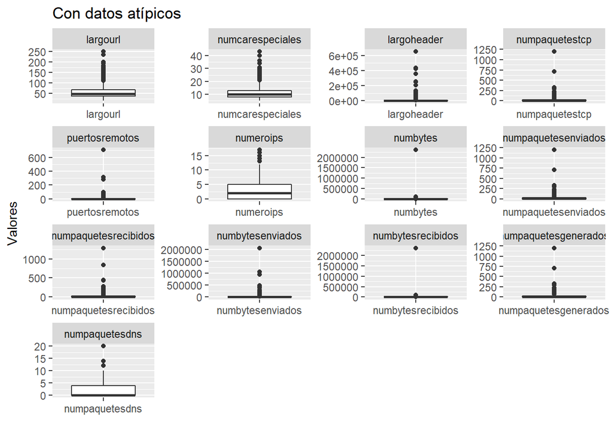

```r
#Remove atipicos
data[pos_atip,] = NA
data = na.omit(data)


data_num = data[,which(sapply(data,class) %notin% c("character", "factor"))]
data_m = melt(data_num)

a3 = ggplot(data_m, aes(variable, value))+geom_boxplot() + facet_wrap(~variable, scales = "free")+ ggtitle("Sin datos atípicos") + ylab("Valores")+ xlab("")
a4 = ggplot(data_m, aes(value))+geom_histogram() + facet_wrap(~variable, scales = "free")+ ggtitle("Sin datos atípicos") + ylab("Frecuencia")+ xlab("")

a1
```

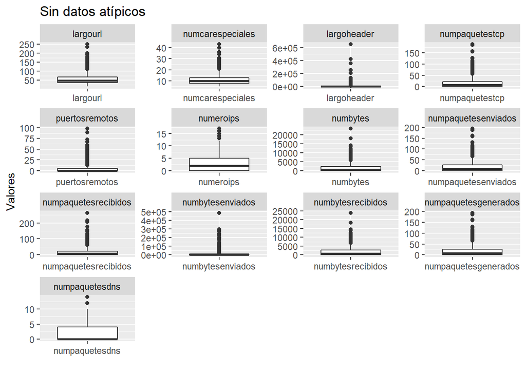

```r
a3
```

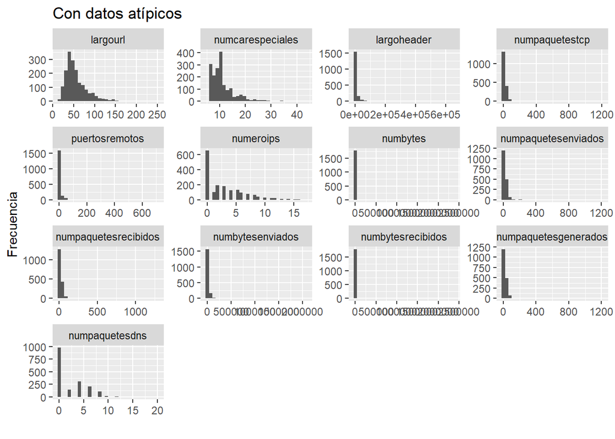

```r
a2
```

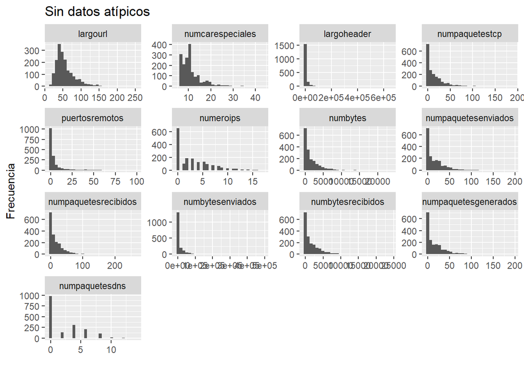

```r
a4
```

Finalmente se identifican 8 registros que presentan valores atípicos en la mayoría de las variables y se procede a eliminarlos de la base de datos.

#### 1.5.2 Análisis gráfico y descriptivo

Con el fin de explorar el comportamiento de algunas variables se realizarán algunos análisis gráficos y descriptivos en función de la variable que identifica como maligna o benigna una página web.

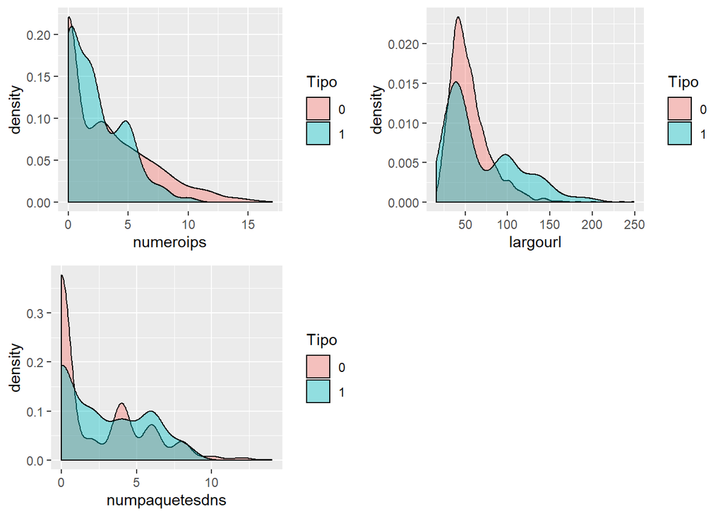

```r
d1=ggplot(data, aes(numeroips))+ geom_density(aes(fill=tipo),alpha=0.4)+labs(fill="Tipo")

d2=ggplot(data, aes(largourl))+ geom_density(aes(fill=tipo),alpha=0.4) +labs(fill="Tipo")

d3=ggplot(data, aes(numpaquetesdns))+ geom_density(aes(fill=tipo),alpha=0.4)+labs(fill="Tipo")

grid.arrange(d1, d2, d3, nrow = 2)
```

En el caso de las variables númericas se observa en los gráficos que para el largourl es más probable que una página web sea maligna cuando esta es mayor a 80. Para el caso del número de paquetes dns, se observa mayor probabilidad de tener una pág benigna cuando esta variable toma valores pequeños, menores a 1. La variable número de ip también nos ayuda a discriminar las páginas web pues aquellas que presentan valores inferiores a 6 tienden a ser malignas.

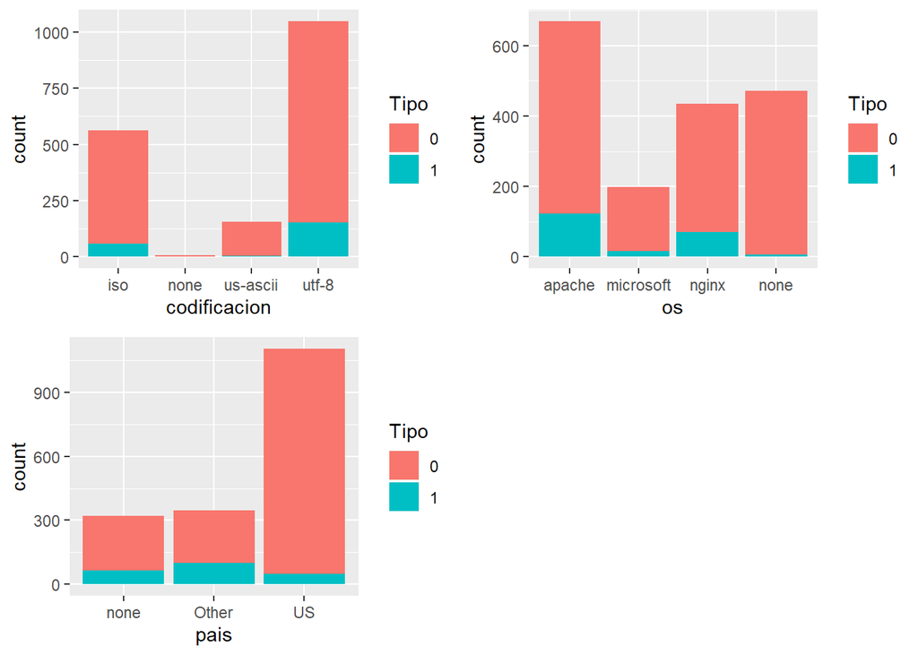

```r
d4 = ggplot(data, aes(codificacion))+ geom_bar(aes(fill=tipo))+labs(fill="Tipo")
d5 = ggplot(data, aes(os))+ geom_bar(aes(fill=tipo))+labs(fill="Tipo")
d6 = ggplot(data, aes(pais))+ geom_bar(aes(fill=tipo))+labs(fill="Tipo")

grid.arrange(d4, d5, d6, nrow = 2)
```

En cuanto a las variables categóricas vemos que en todas predomina que la página web sea benigna, en el caso del país se destaca que el que la página tenga como país a Estados Unidos en su mayoría son benignas. Entre los web servers que se registraron, Apache es el que tiene mayor frecuencia de páginas web malignas. La codificación más frecuente es UTF-8 seguida de la ISO

## 2. Ajuste de modelos predictivos

### 2.1 Protocolo de evaluación y calibración

Para el ajuste de los diferentes modelos se esteblece un 80% de los datos para entrenamiento y un 20% para el test, en la parte del entrenamiento se utilizará el método de k-fold con k=5 para la selección de los hiperparámetros de los diferentes modelos.

### 2.2 Regresión logística

Para el ajuste del modelo logístico no se tendrá en cuenta la variable codificación debido a que una de sus categorías tiene desbalance. Para la selección de las variables en el modelo se utilizará el método Stepwise Forward y el criterio AIC. Los datos que ingresan al modelo se centran y escalan para poder identificar las variables más importantes.

```r
data_model = na.omit(data[, -c(1,4,8)])

set.seed(500)
trainIndex <- createDataPartition(data_model$tipo, p = .8, list = FALSE, times = 1)
length(trainIndex)

webTrain <- data_model[ trainIndex,]
webTest <-  data_model[-trainIndex,]

model_logreg1 <- train(tipo~., webTrain,
                       method="glm", family="binomial",
                       trControl=trainControl(method="cv", number=5),
                       preProcess=c("center", "scale"))

model_logreg1




trainControl=trainControl(method="cv", number=5)
set.seed(123)
model_stepBoth <- train(tipo ~., data = data_model,
                        method = "glmStepAIC", direction ="forward",
                        trControl = trainControl,
                        preProcess=c("center", "scale"),
                        trace=TRUE)
```

Después de realizar la selección de variables el modelo que se escogió tiene un AIC = 689.4 y 12 variables regresoras

```r
model_stepBoth$finalModel
```

```
##
## Call:  NULL
##
## Coefficients:
##          (Intercept)                paisUS        puertosremotos
##             -5.65816              -0.48676              -6.44705
##     numcarespeciales        numpaquetesdns           largoheader
##              2.49903              -0.04121              -2.46398
##             largourl                osnone             paisOther
##             -1.80262              -0.80858               0.27606
##     numbytesenviados  numpaquetesrecibidos             numeroips
##             -5.32521               4.05436              -0.86524
##       numpaquetestcp
##              1.25606
##
## Degrees of Freedom: 1771 Total (i.e. Null);  1759 Residual
## Null Deviance:       1310
## Residual Deviance: 663.4     AIC: 689.4
```

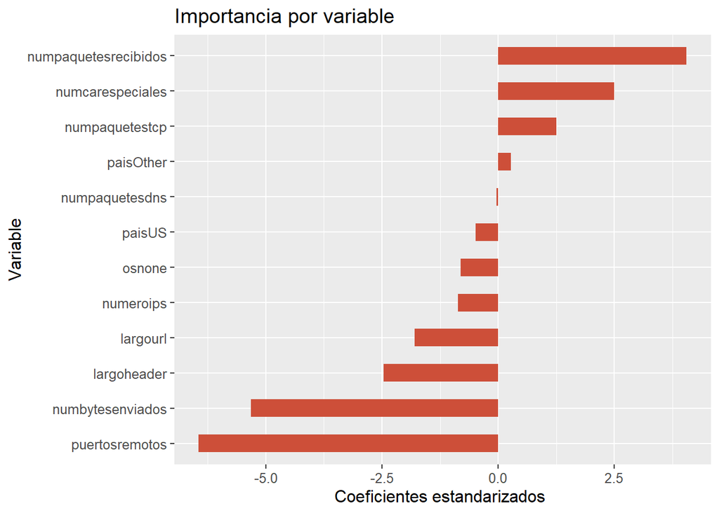

```r
log = data.frame("var"= names(model_stepBoth$finalModel$coefficients)[-1], "coef"=model_stepBoth$finalModel$coefficients[-1])

p <- ggplot(log, aes(x=reorder(var, coef), y=coef)) +
  geom_bar(stat="identity", width=.5, fill="tomato3") +
  labs(title= "Importancia por variable") +
  theme(text = element_text(size=12)) +
  scale_x_discrete(name="Variable") +
  coord_flip()+ylab("Coeficientes estandarizados ")

p
```

```r
# Test
predictions_test<-predict(object=model_stepBoth, webTest)
confusionMatrix(predictions_test, factor(webTest$tipo))$overall[1:2]
```

```
##  Accuracy     Kappa
## 0.9322034 0.6546622
```

```r
# Training
predictions<-predict(object=model_stepBoth, webTrain)
confusionMatrix(predictions, factor(webTrain$tipo))$overall[1:2]
```

```
##  Accuracy     Kappa
## 0.9294781 0.6302631
```

En cuanto a las métricas de desempeño se observa que los valores obtenidos con el set de Training y de Test son similares, también vemos que el accuracy del modelo es superior al baseline y obtenemos un kappa de 0.65 en el test set.

### 2.3 Naive Bayes

Para la construcción de este modelo el primer paso es convertir todas las variables númericas en tipo double. Para la selección de los parámetros se genera un set de posibles valores de laplace, con/sin aproximación kernel y con/sin ajuste.

```r
data_model_naive = na.omit(data[, -c(1,8)])

set.seed(500)
trainIndex <- createDataPartition(data_model_naive$tipo, p = .8, list = FALSE, times = 1)
#length(trainIndex)

webTrain <- data_model_naive[ trainIndex,]
webTest <-  data_model_naive[-trainIndex,]

id= which(sapply(data_model_naive,class)!="factor")
data_model_n = mutate_each(data_model_naive, funs(as.double), id)

tgrid1 = expand.grid(laplace=c(10, 7, 6, 5, 4.5, 4, 3.5, 3, 2, 1, 0.1, 0.01, 0.001, 0.0001, 0),
                     usekernel=c(FALSE), adjust=c(0))
tgrid2 = expand.grid(laplace=c(10, 7, 6, 5, 4.5, 4, 3.5, 3, 2, 1, 0.1, 0.01, 0.001, 0.0001, 0),
                     usekernel=c(TRUE), adjust=c(1))
tgrid = rbind(tgrid1, tgrid2)


webTrainX = webTrain[,-which(names(webTrain)=="tipo")]

set.seed(123)
model_nb5 <- train(webTrainX, webTrain$tipo,
                   method = "naive_bayes",
                   tuneGrid=tgrid,
                   trControl = trainControl)
```

El modelo que mejor ajuste presentó fue aquel con laplace = 10 usando la corrección de kernel y utilizando el ajuste. Se obtuvo un accuracy de 0.83 y un kappa de 0.47 en el set de test.

```r
model_nb5$bestTune
```

```
##    laplace usekernel adjust
## 30      10      TRUE      1
```

```r
# Test
predictions_test<-predict(object=model_nb5, webTest)
 confusionMatrix(predictions_test, factor(webTest$tipo))$overall[1:2]
```

```
##  Accuracy     Kappa
## 0.8389831 0.4727463
```

```r
# Training
predictions<-predict(object=model_nb5, webTrain)
 confusionMatrix(predictions, factor(webTrain$tipo))$overall[1:2]
```

```
##  Accuracy     Kappa
## 0.8794076 0.5865692
```

### 2.4 Árbol de decisión

Ahora procedemos a ajustar árboles de decisión tipo CART, analizaremos 3 escenarios:

**Sin procesar**

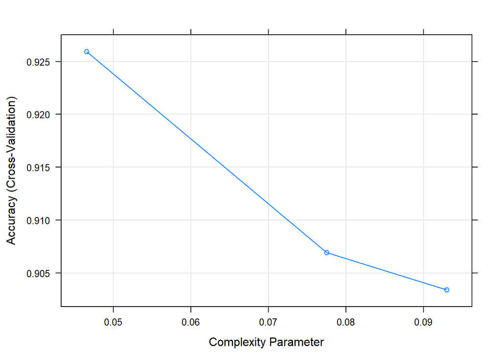

```r
data_model_tree = na.omit(data[, -c(1,8)])

set.seed(500)
trainIndex <- createDataPartition(data_model_tree$tipo, p = .8, list = FALSE, times = 1)

webTrain <- data_model_tree[ trainIndex,]
webTest <-  data_model_tree[-trainIndex,]

trainControl=trainControl(method="cv", number=5)
set.seed(9876)
model_arbol1 <- train(tipo~., webTrain,
                      method='rpart',
                      trControl = trainControl)
plot(model_arbol1)
```

```r
model_arbol1$bestTune
```

```
##           cp
## 1 0.04651163
```

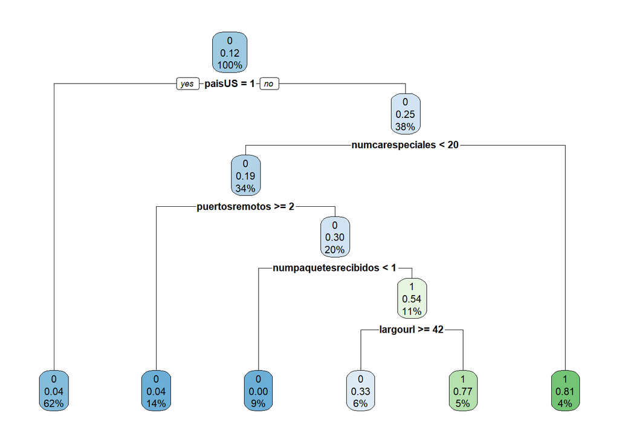

```r
m <- model_arbol1$finalModel
rpart.plot(m)
```

```r
# Test
predictions_test<-predict(object=model_arbol1, webTest)
 confusionMatrix(predictions_test, factor(webTest$tipo))$overall[1:2]
```

```
##  Accuracy     Kappa
## 0.9067797 0.5199310
```

```r
# Training
predictions<-predict(object=model_arbol1, webTrain)
 confusionMatrix(predictions, factor(webTrain$tipo))$overall[1:2]
```

```
##  Accuracy     Kappa
## 0.9294781 0.6260746
```

El accuracy de éste árbol es de 0.9 y el kappa es de 0.519

**Con pre-poda**

Ahora ajustaremos un árbol de decisión utilizando la pre-poda, para esto definimos un set de posibles valores para la profundidad del árbol, para este caso variamos valores de 1 hasta 30.

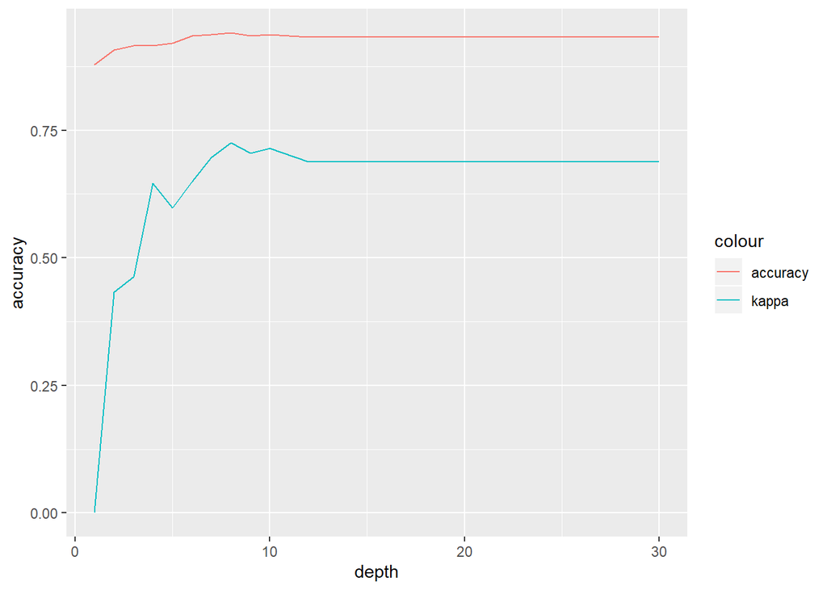

```r
data_model_tree = na.omit(data[, -c(1,8)])

set.seed(500)
trainIndex <- createDataPartition(data_model_tree$tipo, p = .8, list = FALSE, times = 1)

webTrain <- data_model_tree[ trainIndex,]
webTest <-  data_model_tree[-trainIndex,]

depths = c(1, 2, 3, 4, 5, 6, 7, 8, 9, 10, 12, 15, 18, 20, 25, 30)
accuracies = c()
kappas = c()

for(depth in depths) {
  set.seed(9876) # el valor de la semilla, en sí, no es importante, solo que se utilice siempre el mismo
  grid <- data.frame(cp=c(0))
  modelo <- train(tipo~., data = webTrain, method = "rpart",
                   tuneGrid=grid,
                   control = rpart.control(
                     minsplit = 2,
                     minbucket = 1,
                     maxdepth=depth
                   ))
  predicciones <- predict(modelo, newdata=webTest) #type "raw" por defecto
  cm <- confusionMatrix(predicciones,webTest$tipo, mode = "everything")
  accuracies <- c(accuracies, cm$overall[1])
  kappas <- c(kappas, cm$overall[2])
}

df <- data.frame(depth=depths, accuracy=accuracies, kappa=kappas)
ggplot(df, aes(depth)) +
  geom_line(aes(y = accuracy, colour = "accuracy")) +
  geom_line(aes(y = kappa, colour = "kappa"))
```

```r
df[which.max(df$kappa),]
```

```
##   depth accuracy     kappa
## 8     8 0.940678 0.7248094
```

```r
set.seed(9876)
 modelopoda <- train(tipo~., data = webTrain, method = "rpart",
                   tuneGrid=grid,
                   control = rpart.control(
                     minsplit = 2,
                     minbucket = 1,
                     maxdepth=which.max(df$kappa)
                                     ))
```

De acuerdo a los resultados del gráfico se identifica que el mejor accuracy se presenta cuando el árbol tiene una profundida de 8 niveles, tomando el valor de 0.94 en accuracy y 0.72 en kappa.

```r
 # Test
  predicciones <- predict(modelopoda, newdata=webTest)
  confusionMatrix(predicciones,webTest$tipo, mode = "everything")$overall[1:2]
```

```
##  Accuracy     Kappa
## 0.9406780 0.7248094
```

```r
  # Train
  predicciones <- predict(modelopoda, newdata=webTrain)
  confusionMatrix(predicciones,webTrain$tipo, mode = "everything")$overall[1:2]
```

```
##  Accuracy     Kappa
## 0.9873061 0.9392332
```

**Con post-poda**

Finalmente realizamos un árbol decisión con post-poda, para esto generamos un árbol sin ningún nivel de complejidad para posteriormente ajustarlo.

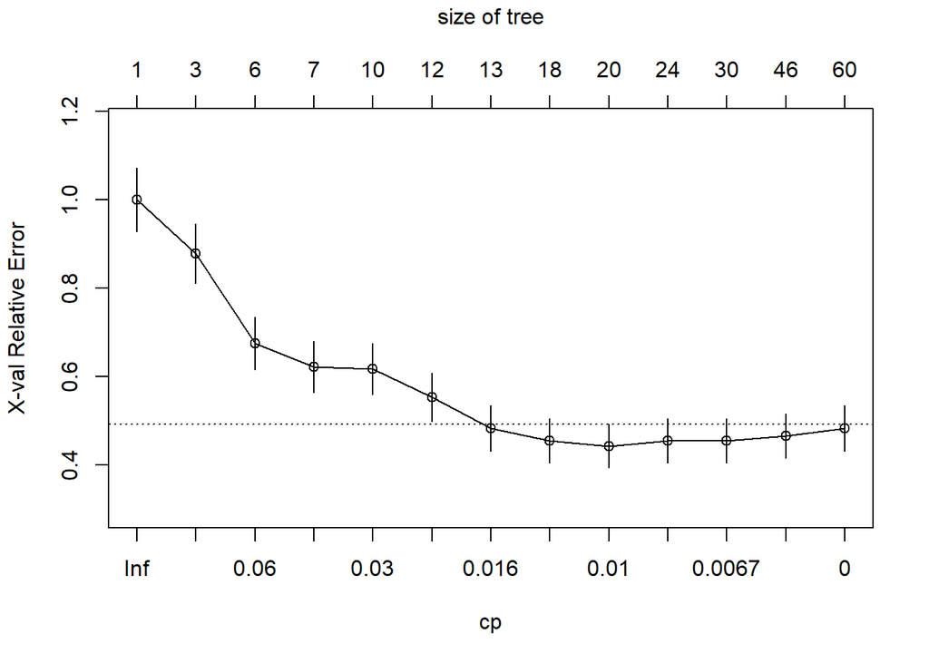

```r
m2 <- rpart(tipo~., data = webTrain,
            control = rpart.control(
              cp=0, # sin prepoda de complejidad
              minsplit = 2, #min instancias para intentar split de un nodo, por defecto es 20
              minbucket = 1, #min instancias en un nodo hoja terminal, por defecto minsplit/3
              maxdepth = 10, #max depth, por defecto es 30
              xval=10 # rpart hace validación cruzada sobre el set de entranamiento para estimar los errores relativos
              ))


plotcp(m2)
```

```r
i = which.min(m2$cptable[,4])
lim_inferior = m2$cptable[i,4] - m2$cptable[i,5]
lim_superior = m2$cptable[i,4] + m2$cptable[i,5]
print(paste("Intervalo de error: [", lim_inferior, ", ", lim_superior, "]"))
```

```
## [1] "Intervalo de error: [ 0.392552566797043 ,  0.491168363435515 ]"
```

```r
indices = which((m2$cptable[,4] >= lim_inferior) & (m2$cptable[,4] <= lim_superior))
indice_corte = min(indices)
umbral_corte_cp = m2$cptable[indice_corte,1]
umbral_corte_cp
```

```
## [1] 0.01453488
```

El anterior gráfico nos sugiere que un nivel de complejidad igual a CP=0.014 nos arroja el mejor modelo.

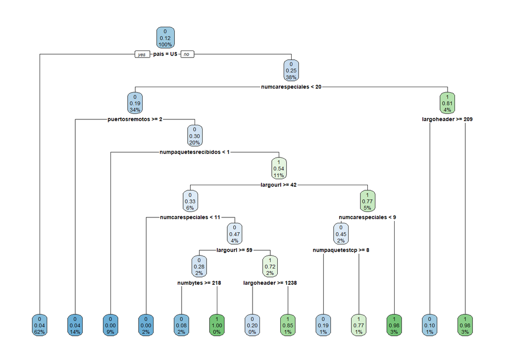

```r
m2 = prune(m2, cp=umbral_corte_cp)
rpart.plot(m2)
```

```r
# Test
predictions_test<-predict(object=m2, webTest, type='class')
 confusionMatrix(predictions_test, factor(webTest$tipo))$overall[1:2]
```

```
##  Accuracy     Kappa
## 0.9350282 0.6578704
```

```r
# Training
predictions<-predict(object=m2, webTrain, type='class')
 confusionMatrix(predictions, factor(webTrain$tipo))$overall[1:2]
```

```
##  Accuracy     Kappa
## 0.9569817 0.7725497
```

También observamos que el árbol final tiene 8 niveles y que al igual que el primer árbol se observa que las 2 primeras variables de segmentación son País Estados Unidos y el número de carácteres especiales. El accuracy del modelo ajustado arroja un valor de 0.93 y un kappa de 0.65

### 2.5 Modelo de ensamble: Random Forest

Para el ensamble ajustaremos un Random Forest, para el ajuste de la complejidad y el número de árboles se realizan los ajustes para diferentes escenarios.

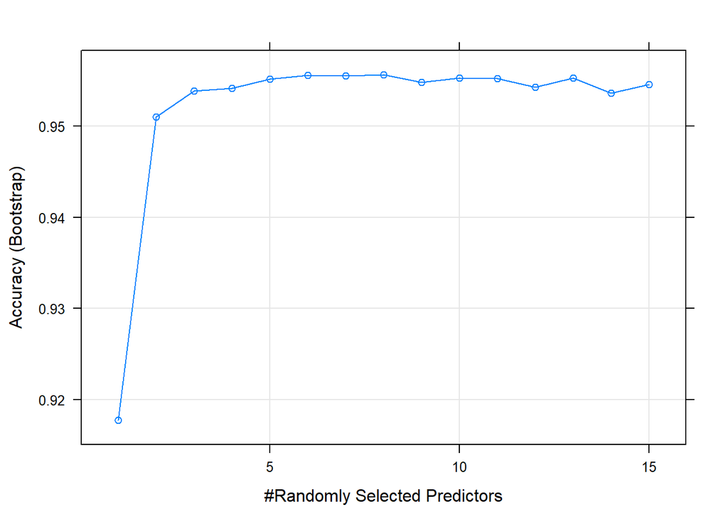

```r
data_model_tree = na.omit(data[, -c(1,8)])

set.seed(500)
trainIndex <- createDataPartition(data_model_tree$tipo, p = .8, list = FALSE, times = 1)

webTrain <- data_model_tree[ trainIndex,]
webTest <-  data_model_tree[-trainIndex,]

control <- trainControl(method='cv',
                        number=5,
                        search='grid')


tunegrid <- expand.grid(.mtry = (1:15))

rf_gridsearch <- train(tipo ~ .,
                       data = webTrain,
                       method = 'rf',
                       metric = 'Accuracy',
                       tuneGrid = tunegrid)

plot(rf_gridsearch)
```

```r
rf_gridsearch$bestTune
```

```
##   mtry
## 8    8
```

Para el nivel de complejidad se determina que mty=8 es el que mejor ajuste presenta. A continuación fijaremos la cantida de árboles a usar:

```r
# Manual Search
seed = 456
metric = "Accuracy"
control <- trainControl(method="cv", number=5, repeats=1, search="grid")
tunegrid <- expand.grid(.mtry=c(8))
modellist <- list()

for (ntree in c(500,1000, 1500, 2000)) {
    set.seed(seed)
    fit <- train(tipo~., data=webTrain, method="rf", metric=metric, tuneGrid=tunegrid, trControl=control, ntree=ntree)
    key <- toString(ntree)
    modellist[[key]] <- fit
}
# compare results
results <- resamples(modellist)
summary(results)
```

```
##
## Call:
## summary.resamples(object = results)
##
## Models: 500, 1000, 1500, 2000
## Number of resamples: 5
##
## Accuracy
##           Min.   1st Qu.    Median      Mean   3rd Qu.     Max. NA's
## 500  0.9542254 0.9575972 0.9681979 0.9647365 0.9718310 0.971831    0
## 1000 0.9542254 0.9575972 0.9681979 0.9640323 0.9683099 0.971831    0
## 1500 0.9542254 0.9575972 0.9717314 0.9654432 0.9718310 0.971831    0
## 2000 0.9542254 0.9575972 0.9681979 0.9640323 0.9683099 0.971831    0
##
## Kappa
##           Min.   1st Qu.    Median      Mean   3rd Qu.      Max. NA's
## 500  0.7479519 0.7828922 0.8436176 0.8162290 0.8512310 0.8554523    0
## 1000 0.7479519 0.7828922 0.8302338 0.8120296 0.8436176 0.8554523    0
## 1500 0.7479519 0.7828922 0.8512310 0.8200664 0.8554523 0.8628045    0
## 2000 0.7479519 0.7828922 0.8302338 0.8120296 0.8436176 0.8554523    0
```

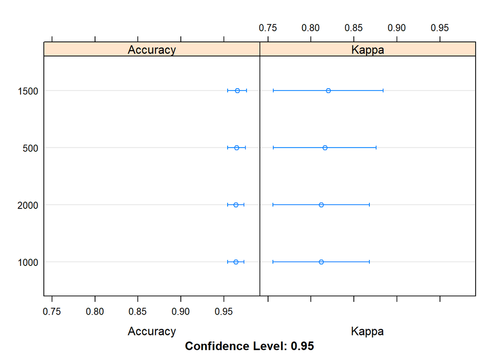

```r
dotplot(results)
```

```r
tunegrid <- expand.grid(.mtry=8)

set.seed(seed)
fit1 <- train(tipo~., data=webTrain, method="rf", metric=metric, tuneGrid=tunegrid, trControl=control, ntree=1500)
```

De acuerdo al gráfico se establece que el número óptimo de árboles es 1500, con esta configuración de parámetros obtenemos un accuracy de 0.96 y un kappa de 0.839.

```r
# Test
predictions_test<-predict(object=fit1, webTest)
 confusionMatrix(predictions_test, factor(webTest$tipo))$overall[1:2]
```

```
##  Accuracy     Kappa
## 0.9689266 0.8399770
```

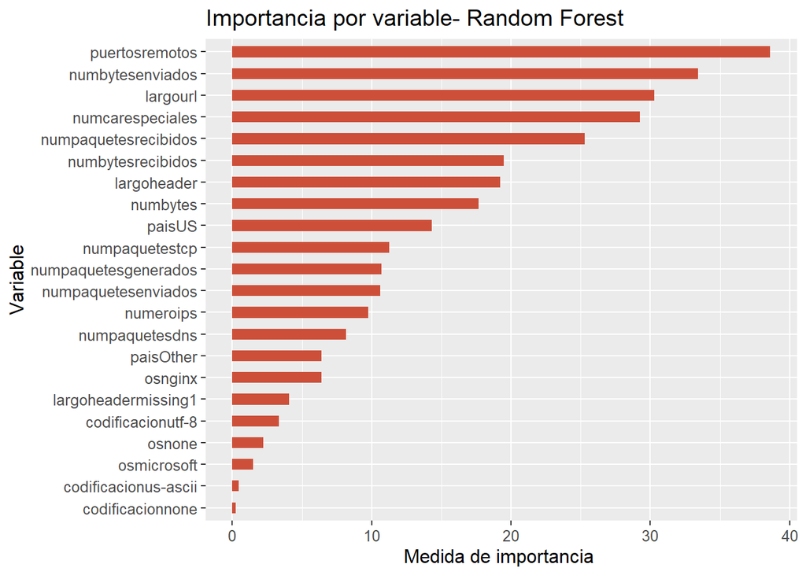

```r
# Training
rfs = summary(results)

trf = c("Accuracy"=rfs$statistics[[1]][3,4],"Kappa"=rfs$statistics[[2]][3,4])

mf = fit1$finalModel
imp = data.frame("var"=rownames(importance(mf)),"value"=importance(mf))

p <- ggplot(imp, aes(x=reorder(var, MeanDecreaseGini), y=MeanDecreaseGini)) +
  geom_bar(stat="identity", width=.5, fill="tomato3") +
  labs(title= "Importancia por variable- Random Forest") +
  theme(text = element_text(size=12)) +
  scale_x_discrete(name="Variable") +
  coord_flip()+ylab("Medida de importancia ")

p
```

### 2.6 Conclusión

Para los diferentes modelos de clasificación ajustados se presentan las métricas del Accuracy y el Kappa tanto en el set de entrenamiento como el set de test, esto con el fin de evaluar si existe sobreajuste en los modelos escogidos.

| **Modelo** | **Set de datos** | **Configuración** | **Accuracy** | **Kappa** |
| --- | --- | --- | --- | --- |
| Logístico | Test | 12 variables, AIC = 689.4 | 0.93 | 0.65 |
|  | Entrenamiento |  | 0.93 | 0.63 |
| Naive Bayes | Test | Laplace=10, usekernel=TRUE, adjust=1 | 0.84 | 0.47 |
|  | Entrenamiento |  | 0.88 | 0.59 |
| Árbol de decisión 1 | Test | Sin procesamiento, CP= 0.0348 | 0.91 | 0.52 |
|  | Entrenamiento |  | 0.93 | 0.63 |
| Árbol de decisión 2 | Test | Pre-poda, depth=8 | 0.94 | 0.72 |
|  | Entrenamiento |  | 0.99 | 0.94 |
| Árbol de decisión 3 | Test | Post-poda, CP=0.014 | 0.94 | 0.66 |
|  | Entrenamiento |  | 0.96 | 0.77 |
| Random Forest | Test | ntree = 1500, mtry = 8 | 0.97 | 0.84 |
|  | Entrenamiento |  | 0.97 | 0.82 |

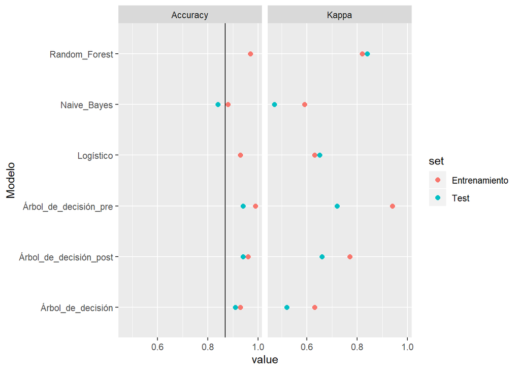

```r
setwd("C:/Users/lllanos/Dropbox/ICESI/Semestre I/Fundamentos de analítica I/Proyecto final")

df = read.csv("resumen.csv", header = T)
df =melt(df, id.vars = c("Modelo", "set"))
ggplot(df, aes(Modelo,value, color=set))+ geom_point( size=2)+ coord_flip()+facet_grid(~variable)+
  geom_hline(data=filter(df, variable=="Accuracy"), aes(yintercept=0.87), colour="black")
```

En conclusión, el modelo que presentó mejor desempeño para dectectar cuando una página web es beninga o maligna fue Random Forest, con un Accuracy de 0.97 y un Kappa de 0.84, además fue el modelo con el menor sobreajuste.

También se destaca que la mayoría de los modelos tuvieron un Accuracy superior al baseline (0.87, línea negra) a excepción del modelo Naive Bayes, el cual fue el de peor desempeño de acuerdo a las métricas analizadas.

## 3. Cambio de representación y segmentación de los casos

### 3.1 Análisis de componentes principales (ACP)

### 3.2 Clúster k-means

### 3.3 Clúster Jerárquico

### 3.4 Conclusiones

## Análisis de componentes principales

El primer paso para realizar el análisis de componentes principales es verificar que las variables se encuentren correlacionadas, este procedimiento se realizó tanto para los casos malignos como para todos los casos, con el objetivo de comparar los resultados.

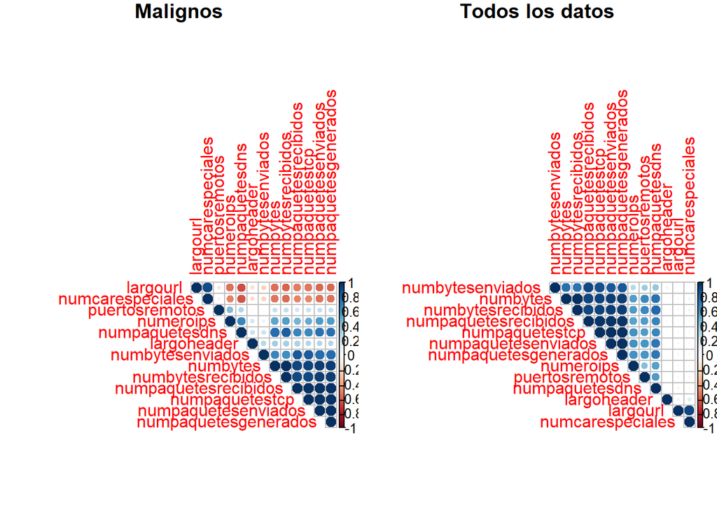

```r
library("factoextra")
library("FactoMineR")

data_3 <- cbind.data.frame(data_num,tipo=data$tipo) %>% filter(tipo==1) %>% dplyr::select(-tipo)
data_3_all <- cbind.data.frame(data_num,tipo=data$tipo) %>% dplyr::select(-tipo)

par(mfrow = c(1, 2))
corMat <- cor(data_3)
corrplot(corMat, type="upper", order="hclust",title= "Malignos",mar=c(0,0,1,0))

corMat_all <- cor(data_3_all)
corrplot(corMat_all, type="upper", order="hclust",title= "Todos los datos",mar=c(0,0,1,0))
```

Del grafico de correlación para los datos malignos se observa una fuerte o moderada correlación positiva entre las variables asociadas a las tranferencias cliente-servidor, adicionalmente las variables largourl y numcarespeciales presentan una moderada o debil correlación negativa con la mayoria de las variables asociadas a las transferencias cliente-servidor, por ejemplo entre más caracteres tenga la url, se espera que en promedio se generen menos paquetes DNS en la comunicación cliente-servidor. En cuanto al grafico con todos los datos se puede observar que al ingresar los datos veningos se pierden las corelaciones negativas observadas para las variables largourl y numcarespeciales, es decir los registros venignos se ven influeciados en gran medida por estas variables.

```r
res.pca <- PCA(data_3,ncp=4,  graph = FALSE)
get_eig(res.pca)
```

```
##          eigenvalue variance.percent cumulative.variance.percent
## Dim.1  8.206399e+00     6.312614e+01                    63.12614
## Dim.2  1.675007e+00     1.288467e+01                    76.01082
## Dim.3  1.126904e+00     8.668490e+00                    84.67930
## Dim.4  8.643756e-01     6.649043e+00                    91.32835
## Dim.5  5.110024e-01     3.930787e+00                    95.25914
## Dim.6  3.653797e-01     2.810613e+00                    98.06975
## Dim.7  1.177880e-01     9.060615e-01                    98.97581
## Dim.8  9.998621e-02     7.691247e-01                    99.74493
## Dim.9  2.100867e-02     1.616051e-01                    99.90654
## Dim.10 1.212379e-02     9.325993e-02                    99.99980
## Dim.11 2.604910e-05     2.003777e-04                   100.00000
## Dim.12 3.103497e-31     2.387306e-30                   100.00000
## Dim.13 3.865349e-34     2.973346e-33                   100.00000
```

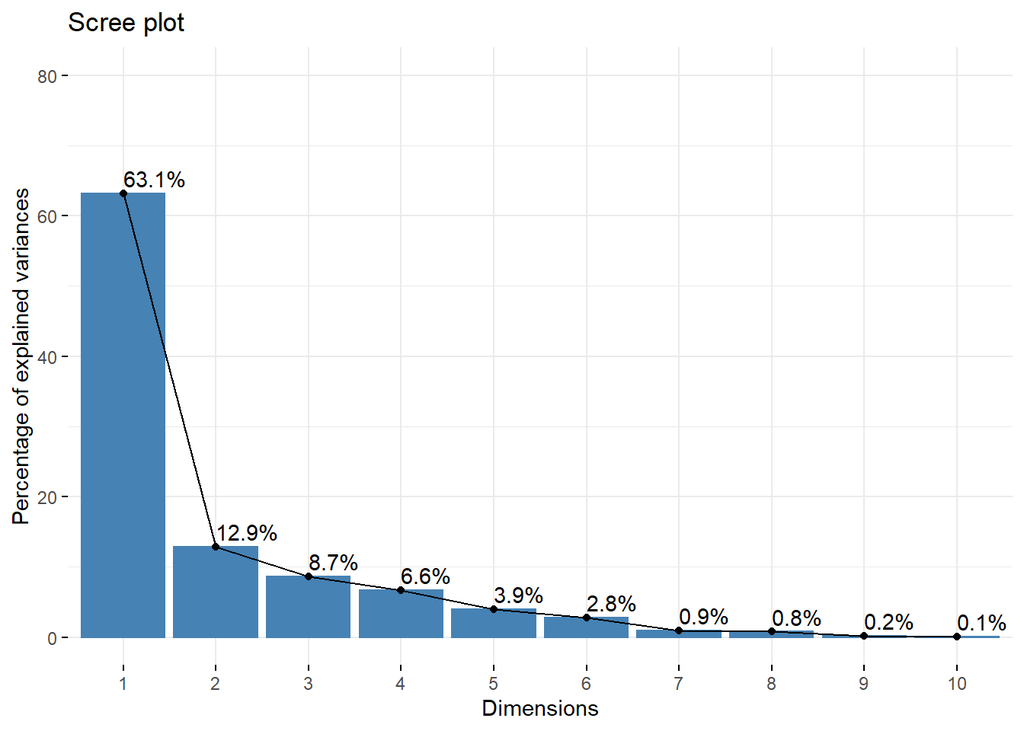

```r
fviz_screeplot(res.pca, addlabels = TRUE, ylim = c(0, 80))
```

De los resultados obtenidos se puede observar que para acumular un 90% de la información de los datos originales, es necesario retener 4 componentes principales que acumulan el 91.3% de la variabilidad total observada.

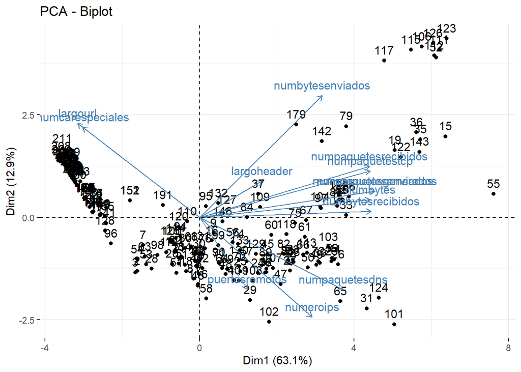

```r
fviz_pca_biplot(res.pca)
```

El grafico de individuos y variables se puede observar que las variables largourl y numcarespeciales se encuentran en dirección opuesta a todas las demás variables,es decir presentan un comportamiento inverso con respecto a los demás, adicionalmente estas variables se encuentran aportando a la construcción de las dos primeras componentes, mientras que las variables asociadas a las transferencias cliente-servidor se encuentran en la misma dirección de la componente 1, por lo tanto la componente 1 va a representar muy bien estas variables, finalmente las variables numpaquetesdns y numeroips son importantes en la construcción de ambas componentes, en cuanto a las páginas web se puede observar que se distinguen 3 grupos diferentes en el primer plano factorial.

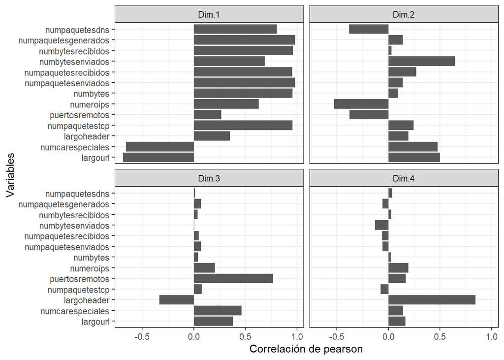

```r
load_cor <- t(cor(res.pca$ind$coord[,1:4,drop=F],data_3))
data_plot=melt(load_cor)

ggplot(aes( x = factor(Var1), y=value),data =data_plot ) +
  geom_bar(stat = "identity", show.legend = FALSE) +
  coord_flip()+
  facet_wrap(~ factor(Var2)) +
  ylab("Correlación de pearson") +
  xlab("Variables") +
  theme_bw()
```

Finalmente se muestran la contribucción de cada una de las variables a las primeras 4 componentes en terminos de la correlación de pearson, donde finalmente se comprueba que la primera componente está compuesta principalmente de las variables asociadas a las transferencias cliente-servidor con correlaciones en su mayoria superiores a 0.6, mientras que la segunda componente se encuentra compuesta principalmente por las variables largourl, numcarespeciales y numbytesenviados, adicionalmente se observa que el puertosremotos está generando en su mayoria el patron de la tercera componente,la cuarta componente está construida principalmente de la variables largoheader.

## Clustering K-means

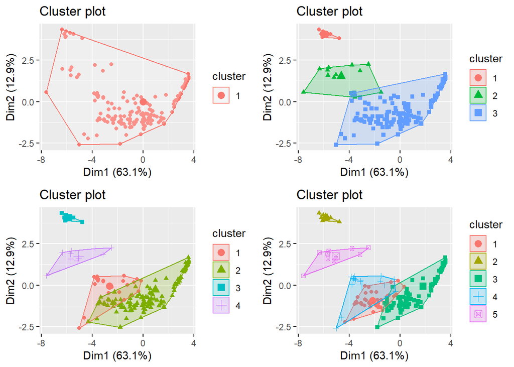

```r
set.seed(1234)
kmClustering0 <- kmeans(data_3, 1, nstart=100, iter.max=150)
kmClustering1 <- kmeans(data_3, 3, nstart=100, iter.max=150)
kmClustering2 <- kmeans(data_3, 4, nstart=100, iter.max=150)
kmClustering3 <- kmeans(data_3, 5, nstart=100, iter.max=150)

library(gridExtra)

c0 <- fviz_cluster(kmClustering0, data_3, geom="point")#labelsize = 5)
c1 <- fviz_cluster(kmClustering1, data_3, geom="point")#labelsize = 5)
c2 <- fviz_cluster(kmClustering2, data_3, geom="point")#labelsize = 5)
c3 <- fviz_cluster(kmClustering3, data_3, geom="point")#labelsize = 5)

grid.arrange(c0,c1,c2,c3,ncol=2)
```

De manera visual solo enfocándose en el primer plano factorial el número de clúster ideal que se ajusta mejor al conjunto de datos parece ser el número 3.

## Determinación del número de clusters K

### Método del codo

```r
vars <- apply(data_3,2,var)
sumvars <- sum(vars)
wss <- (nrow(data_3) - 1)*sumvars # Para obtener el TSS multiplicamos la varianza por (N-1)

# Para K>1, calculamos las diferencias cuadradas en un ciclo
set.seed(1234)
maxK <- 10
for (k in 2:maxK) {

  wssK <- 0 # Aquí va a quedar el total de WSS para el k actual
  kmClustering <- kmeans(data_3, k, nstart=30, iter.max=150)
  data_3$clusters <- kmClustering$cluster

  for(i in 1:k) { # Recorrido de los clusters

    clusterData <- subset(data_3, clusters==i)
    centroide <- apply(clusterData, 2, FUN=mean)
    wssK <- wssK + sum(apply(clusterData, 1, FUN=function(fila) {sum((fila-centroide)^2)}))
  }
  # Una vez calculado el wss del K actual, lo guardamos en el vector de WSS
  wss[k] <- wssK
}
wss
```

```
##  [1] 44970384051 10296783686  5286481633  2288151562  1760060735
##  [6]  1429194460   984887082  1152401187   708093809   687206098
```

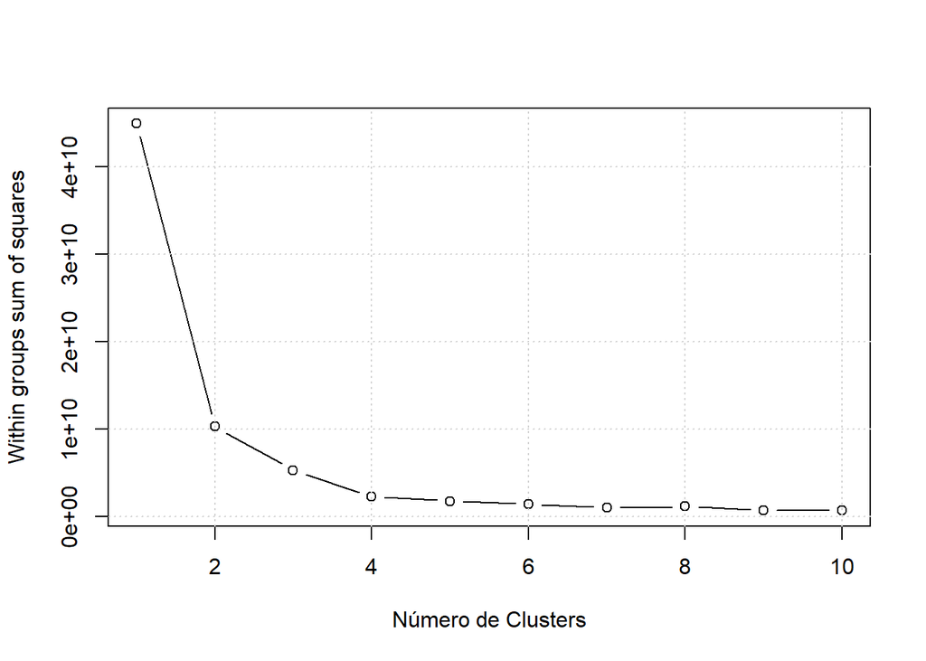

```r
plot(1:maxK, wss, type = "b", xlab = "Número de Clusters", ylab = "Within groups sum of squares")
grid()
```

### Método de Calinski-Harabasz

```r
library(fpc)

set.seed(11111)
kmClusteringRuns.ch <- kmeansruns(data_3, krange=1:10, criterion="ch")
summary(kmClusteringRuns.ch)
```

```
##              Length Class  Mode
## cluster      215    -none- numeric
## centers      126    -none- numeric
## totss          1    -none- numeric
## withinss       9    -none- numeric
## tot.withinss   1    -none- numeric
## betweenss      1    -none- numeric
## size           9    -none- numeric
## iter           1    -none- numeric
## ifault         1    -none- numeric
## crit          10    -none- numeric
## bestk          1    -none- numeric
```

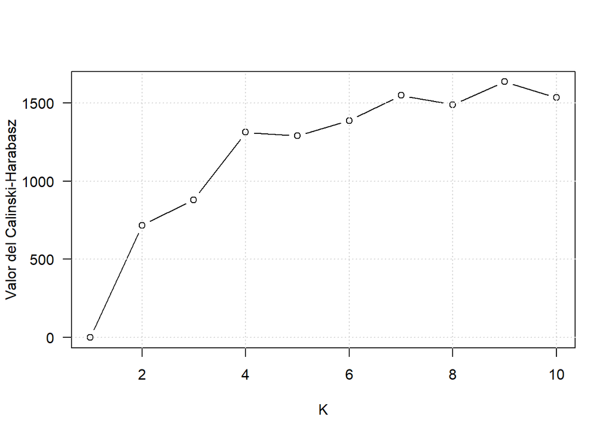

```r
val_ch <- kmClusteringRuns.ch$crit
rm(kmClusteringRuns.ch)

plot(val_ch,type="b",las=1,xlab="K",ylab="Valor del Calinski-Harabasz")
grid()
```

Encontramos que según el criterio Calinski Harabasz el mejor particionamiento es con k=9, pero como tenemos la restricción de buscar de 3 a 5 clusters, podemos ver que k=4 tiene valor de CH mayor en comparación con 3 y 5 clusters.

### Método de la silueta

```r
library(cluster)

distancias <- dist(data_3)

# Iteramos de K=2 a 8
val_k <- 2:10
val_sil<- 0
for(k in val_k) {
  resultadoKMeansK <- kmeans(data_3, centers = k, nstart =30, iter.max=150)
  sil <- silhouette(resultadoKMeansK$cluster, dist(data_3))
  val_sil[k-1] <- mean(sil[, "sil_width"])
}

rm(distancias, resultadoKMeansK, sil)
gc()
```

```
##            used  (Mb) gc trigger  (Mb) max used  (Mb)
## Ncells  3193150 170.6    6387182 341.2  6387182 341.2
## Vcells 10937682  83.5   33771661 257.7 50893232 388.3
```

```r
val_sil
```

```
## [1] 0.8609929 0.7816269 0.7382675 0.6178849 0.6415698 0.6307252 0.6103648
## [8] 0.5957352 0.6188222
```

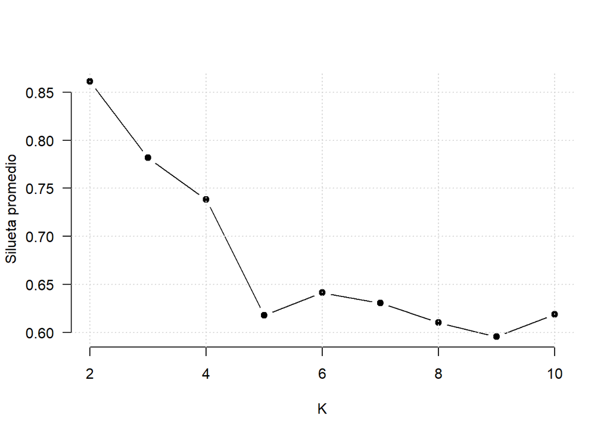

```r
plot(val_k, val_sil,las=1,
       type = "b", pch = 19, frame = FALSE,
       xlab = "K",
       ylab = "Silueta promedio")
grid()
```

Encontramos que, según el criterio de silueta promedio, entre 3 y 5, el mejor particionamiento se logra con K=3 con una silueta promedio de 0.78, ahora veamos los perfiles de las siluetas de los 3 clusterings (con K igual a 3, 4 y 5).

```r
k <- 3
set.seed(1234)
kmClustering3 <- kmeans(data_3, k, nstart=100, iter.max=150)
silueta <- silhouette(kmClustering3$cluster, dist(data_3))
f1 =fviz_silhouette(silueta, label = FALSE, print.summary = TRUE, main="Silueta para K=3")
```

```
##   cluster size ave.sil.width
## 1       1    8          0.99
## 2       2  195          0.85
## 3       3   12          0.53
```

```r
k <- 4
set.seed(1234)
kmClustering4 <- kmeans(data_3, k, nstart=100, iter.max=150)
silueta <- silhouette(kmClustering4$cluster, dist(data_3))
f2=fviz_silhouette(silueta, label = FALSE, print.summary = TRUE, main="Silueta para K=4")
```

```
##   cluster size ave.sil.width
## 1       1   10          0.53
## 2       2   25          0.48
## 3       3  172          0.78
## 4       4    8          0.99
```

```r
k <- 5
set.seed(1234)
kmClustering5 <- kmeans(data_3, k, nstart=100, iter.max=150)
silueta <- silhouette(kmClustering5$cluster, dist(data_3))
f3=fviz_silhouette(silueta, label = FALSE, print.summary = TRUE, main="Silueta para K=5")
```

```
##   cluster size ave.sil.width
## 1       1    8          0.99
## 2       2   48          0.33
## 3       3  131          0.72
## 4       4   10          0.51
## 5       5   18          0.54
```

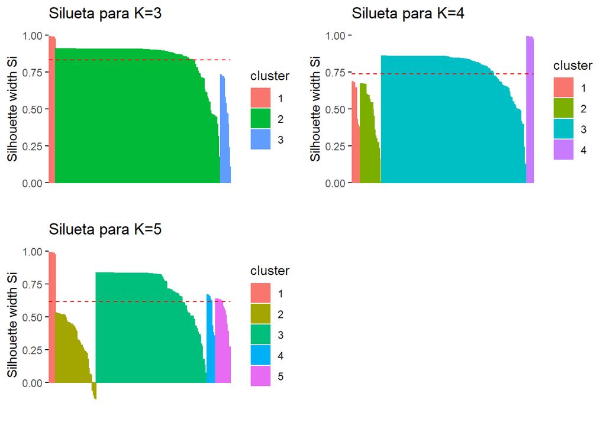

```r
grid.arrange(f1,f2,f3,ncol=2)
```

Podemos ver que con K=5 las siluetas de cada cluster son peores que con K=3 o K=4. En estos dos útlimos clusterings, tenemos un gran cluster que posee valores de silueta positivos, y no se presentan sitios web con siluetas negativas.

### Bootstrap de los cluster

```r
set.seed(3333)
modelo_bootstrap_k3 <- clusterboot(data_3, clustermethod = kmeansCBI, krange=3, B=100, iter.max=150)

modelo_bootstrap_k4 <- clusterboot(data_3, clustermethod = kmeansCBI, krange=4, B=100, iter.max=150)

modelo_bootstrap_k5 <- clusterboot(data_3, clustermethod = kmeansCBI, krange=4, B=100, iter.max=150)
```

```r
k_3=cbind.data.frame(mean_jacard=modelo_bootstrap_k3$bootmean #vector de las estabilidades de cada cluster (promedio de Jaccard)
, disolucion=modelo_bootstrap_k3$bootbrd # número de disoluciones de los clusters en los B runs ejecutados (Jaccard < 0.5)
, recuperaciones=modelo_bootstrap_k3$bootrecover )# número de recuperaciones de los clusters en los B runs ejecutados (Jaccard > 0.75)

k_3
```

```
##   mean_jacard disolucion recuperaciones
## 1   0.7417610         38             53
## 2   0.9559121          0            100
## 3   0.6230171         42             25
```

```r
k_4=cbind.data.frame(mean_jacard=modelo_bootstrap_k4$bootmean #vector de las estabilidades de cada cluster (promedio de Jaccard)
, disolucion=modelo_bootstrap_k4$bootbrd # número de disoluciones de los clusters en los B runs ejecutados (Jaccard < 0.5)
, recuperaciones=modelo_bootstrap_k4$bootrecover )# número de recuperaciones de los clusters en los B runs ejecutados (Jaccard > 0.75)

k_4
```

```
##   mean_jacard disolucion recuperaciones
## 1   0.8886605          3             78
## 2   0.9185860          0             87
## 3   0.8290952         28             72
## 4   0.8345103         17             68
```

```r
k_5=cbind.data.frame(mean_jacard=modelo_bootstrap_k5$bootmean #vector de las estabilidades de cada cluster (promedio de Jaccard)
, disolucion=modelo_bootstrap_k5$bootbrd # número de disoluciones de los clusters en los B runs ejecutados (Jaccard < 0.5)
, recuperaciones=modelo_bootstrap_k5$bootrecover )# número de recuperaciones de los clusters en los B runs ejecutados (Jaccard > 0.75)

k_5
```

```
##   mean_jacard disolucion recuperaciones
## 1   0.8506399         13             72
## 2   0.9327745          0             93
## 3   0.8522965         24             75
## 4   0.8794785          3             78
```

```r
resumen= cbind.data.frame(c(3,4,5),rbind.data.frame(apply(k_3,2,mean),apply(k_4,2,mean),apply(k_5,2,mean)))
colnames(resumen)=c("k",colnames(k_5))
resumen
```

```
##   k mean_jacard disolucion recuperaciones
## 1 3   0.7735634   26.66667       59.33333
## 2 4   0.8677130   12.00000       76.25000
## 3 5   0.8787973   10.00000       79.50000
```

### Resumen de selección del K

A continuación se muestra un resumen de las metodologías utilizadas para seleccionar el número de particionamientos en los datos.

[output not shown]